# Lecture 4: Principal Components Analysis (PCA) and Baysian method

*`@prepared by Hoang Duc Thuong, Department of Space and Applications, USTH.`* hoang-duc.thuong@usth.edu.vn

```python
import matplotlib
params = {
	'axes.labelsize': 30,
	'font.size': 28,
	'legend.fontsize': 26,
	'xtick.labelsize': 30,
	'ytick.labelsize': 30,
	'lines.linewidth': 4,
	'text.usetex': False,
	# 'figure.autolayout': True,
	'ytick.right': True,
	'xtick.top': True,

	'figure.figsize': [10, 8], # instead of 4.5, 4.5
	'axes.linewidth': 2.5,

	'xtick.major.size': 26,
	'ytick.major.size': 26,
	'xtick.minor.size': 26,
	'ytick.minor.size': 26,

	'xtick.major.width': 2.5,
	'ytick.major.width': 2.5,
	'xtick.minor.width': 2.5,
	'ytick.minor.width': 2.5,

	'xtick.major.pad': 10,
	'ytick.major.pad': 10,
	#'xtick.minor.pad': 14,
	#'ytick.minor.pad': 14,

	'xtick.direction': 'in',
	'ytick.direction': 'in',
   }
matplotlib.rcParams.update(params)

%matplotlib inline
```

```python
import matplotlib.pyplot as plt
import numpy as np
```

# 0. Matrix

[figure not shown]

```python
np.eye(3)  # ones on the main diagonal
```

```
array([[1., 0., 0.],
       [0., 1., 0.],
       [0., 0., 1.]])
```

```python
np.eye(4,k=-1)  # the k order of the diagonal
```

```
array([[0., 0., 0., 0.],
       [1., 0., 0., 0.],
       [0., 1., 0., 0.],
       [0., 0., 1., 0.]])
```

```python
np.diag([1, 3, 4, 6]) # Diagonal matrix
```

```
array([[1, 0, 0, 0],
       [0, 3, 0, 0],
       [0, 0, 4, 0],
       [0, 0, 0, 6]])
```

```python
a = np.array([[1, 2, 3], [4, 5, 6], [7, 8, 9]])
a
```

```
array([[1, 2, 3],
       [4, 5, 6],
       [7, 8, 9]])
```

```python
np.diag(a, k = 0)
```

```
array([1, 5, 9])
```

```python
a = np.random.randn(3, 4) # create a random numpy array with shape = (3, 4)
a
```

```
array([[-0.68781996, -0.17723244,  0.59251046,  0.03638398],
       [-1.3102492 ,  1.03898163,  0.05275621, -0.73359979],
       [ 0.72372792, -1.83192494,  0.52188742, -1.0392707 ]])
```

```python
A = np.array([[1., 5], [2, 3]])
B = np.array([[5., 8], [7, 3]])
```

```python
A
```

```
array([[1., 5.],
       [2., 3.]])
```

```python
B
```

```
array([[5., 8.],
       [7., 3.]])
```

```python
A*B  ## Multiply each value in the matrix position
```

```
array([[ 5., 40.],
       [14.,  9.]])
```

```python
np.transpose(A)
```

```
array([[1., 2.],
       [5., 3.]])
```

## Matrix and vector

```python
a = np.arange(9).reshape(3, -1)   # we just need to know 1 dimension (=3),
                                   # python will fild the rest, we just need put "-1"
a
```

```
array([[0, 1, 2],
       [3, 4, 5],
       [6, 7, 8]])
```

```python
b = np.array([1., 2, 5])
b
```

```
array([1., 2., 5.])
```

```python
a+b   # will sum in every elements
```

```
array([[ 1.,  3.,  7.],
       [ 4.,  6., 10.],
       [ 7.,  9., 13.]])
```

```python
a*b  # will multiply every element
```

```
array([[ 0.,  2., 10.],
       [ 3.,  8., 25.],
       [ 6., 14., 40.]])
```

if we want to product matrix way, we use `.dot()` or `np.dot()`

```python
a.dot(b)
```

```
array([12., 36., 60.])
```

```python
np.dot(a,b)
```

```
array([12., 36., 60.])
```

```python
c = np.arange(12).reshape(3, -1)
c
```

```
array([[ 0,  1,  2,  3],
       [ 4,  5,  6,  7],
       [ 8,  9, 10, 11]])
```

```python
np.dot(a,c)
```

```
array([[ 20,  23,  26,  29],
       [ 56,  68,  80,  92],
       [ 92, 113, 134, 155]])
```

```python
# create numpy 2d-array
m = np.array([[1, 2],[8, 9]])

print("Printing the Original square array:\n",m)

# finding eigenvalues and eigenvectors
w, v = np.linalg.eig(m)    # = scipy.linalg.eig

# printing eigen values
print("Printing the Eigen values of the given square array:\n",w)

# printing eigen vectors
print("Printing Right eigenvectors of the given square array:\n",v)
```

```
Printing the Original square array:
 [[1 2]
 [8 9]]
Printing the Eigen values of the given square array:
 [-0.65685425 10.65685425]
Printing Right eigenvectors of the given square array:
 [[-0.77007615 -0.20280301]
 [ 0.63795197 -0.97921956]]
```

```python
# create numpy 2d-array
m = np.array([[1, 2, 3],
              [7, 8, 9],
              [4, 5, 6]])

print("Printing the Original square array:\n", m)

# finding eigenvalues and eigenvectors
w, v = np.linalg.eig(m)

# printing eigen values
print("Printing the Eigen values of the given square array:\n",w)

# printing eigen vectors
print("Printing Right eigenvectors of the given square array:\n",v)
```

```
Printing the Original square array:
 [[1 2 3]
 [7 8 9]
 [4 5 6]]
Printing the Eigen values of the given square array:
 [ 1.55777472e+01 -5.77747211e-01  5.89124644e-16]
Printing Right eigenvectors of the given square array:
 [[ 0.22048676  0.75018389  0.40824829]
 [ 0.82384859 -0.65967897 -0.81649658]
 [ 0.52216768  0.04525246  0.40824829]]
```

## Covariance matrix

- Covariance always measures between 2 dimensions.

$$Cov(x,y) = \frac{\sum_{i=1}^N \left( x_i - \overline{x} \right) \left( y_i - \overline{y} \right) }{N-1}$$

- Covariance matrix of 3 dimentional variable:

$$C = \begin{pmatrix} cov(x,x) & cov(x,y) & cov(x,z) \\ cov(y,x) & cov(y,y) & cov(y,z) \\ cov(z,x) & cov(z,y) & cov(z,z) \end{pmatrix}$$

- Covariance matrix of 2 dimentional variable:

$$C = \begin{pmatrix} cov(x,x) & cov(x,y) \\ cov(y,x) & cov(y,y) \\ \end{pmatrix}$$

# 1. Principal Components Analysis (PCA)

- Principal component analysis (PCA) is a statistic procedure that uses the correlations between the variables to identify which combinations of variables capture most information about the dataset. In a simple words, PCA reducing the number of dimensions.
- Geometrically, it identifies the directions in which the cloud of variables is most elongated.
- Mathematically, it determines the eigenvectors of the covariance matrix and sorts them in importance according to their corresponding eigenvalues

[figure not shown]

Source: https://machinelearningcoban.com/2017/06/15/pca/

```python
from scipy import stats

direc = '/Users/USTH/TEACHING/SA2.7DataAnalysisandVisualization/data/'

data = np.loadtxt(direc+'correlation_example.dat')
x,y = data[:,0],data[:,1]
```

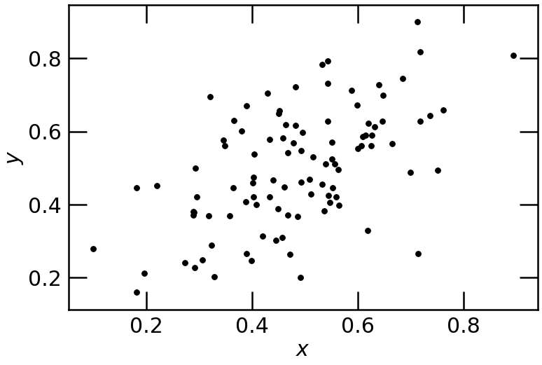

```python
fig, ax = plt.subplots(figsize=(12, 8))
ax.scatter(x,y,marker='o',s=60, color='black')
plt.xlabel(r'$x$')
plt.ylabel(r'$y$')

plt.savefig("correlation_example_2D.png",dpi=300)
```

```python
# Evaluate Pearson correlation coefficient r
r,p = stats.pearsonr(x,y)
print('correlation coefficent',r, '\n p-value',p)

# Evaluate the mean
xmu,ymu = np.mean(x),np.mean(y)
print('x mean', xmu, '\n y mean', ymu)
```

```
correlation coefficent 0.548341521611091
 p-value 3.513624460312244e-09
x mean 0.4837711987590891
 y mean 0.5000073026555047
```

### Making the covariance matrix

```python
cov_xy = sum( (x - xmu)*(y-ymu) ) / ( len(x) -1 )
cov_xy
```

```
0.012854451498747805
```

```python
cov_xx = np.var(x)
cov_xx
```

```
0.02108665776632983
```

```python
cov_yy = np.var(y)
cov_yy
```

```
0.025542739480579026
```

```python
# create numpy 2d-array
m = np.array([[cov_xx, cov_xy],
              [cov_xy, cov_yy]])

print("The Original square array:\n",m)

# finding eigenvalues and eigenvectors
w, v = np.linalg.eig(m)

# printing eigen values
print("The Eigenvalues of the given square array:\n",w)

# printing eigen vectors
print("The Eigenvectors of the given square array:\n", v)
```

```
The Original square array:
 [[0.02108666 0.01285445]
 [0.01285445 0.02554274]]
The Eigenvalues of the given square array:
 [0.01026858 0.03636081]
The Eigenvectors of the given square array:
 [[-0.76510847 -0.64390141]
 [ 0.64390141 -0.76510847]]
```

The new coordinate system:

$\vec{x} = (x,y) = ( \bar{x}, \bar{y} ) + PCA_1 \vec{v_1} + PCA_2 \vec{v_2}$

```python
from sklearn.decomposition import PCA   # Machine learning tool!
```

```python
# Determine the eigenvalues and eigenvectors of the example correlation dataset
pca = PCA(n_components=2)
data = np.transpose(np.array([x,y]))
pca.fit(data)

eigval = pca.explained_variance_
eigvec = pca.components_

print('Eigenvalue : \n', eigval)
print('Eigenvector : \n',eigvec)

l1,l2 = eigval[0],eigval[1]   # lambda_1, lambda_2
v1,v2 = eigvec[:,0],eigvec[:,1]

print('Eigenvalue 1 =',l1,'eigenvector 1 =',v1)
print('Eigenvalue 2 =',l2,'eigenvector 2 =',v2)
```

```
Eigenvalue :
 [0.03660018 0.01050022]
Eigenvector :
 [[ 0.64325113  0.76565526]
 [ 0.76565526 -0.64325113]]
Eigenvalue 1 = 0.036600176954389524 eigenvector 1 = [0.64325113 0.76565526]
Eigenvalue 2 = 0.010500224305114374 eigenvector 2 = [ 0.76565526 -0.64325113]
```

- Eigenvectors and dataset are plotted in the same frame, the lengths of the vectors is scaled to promotional to square root of eigenvalues.
- The eigenvectors indicate the direction of the data points as “principal axes” => PCA axes.
- The size of eigenvalues means the spread (variance) of data along each principal axis.
- In this example: size of eigenvalues = 2. There are 2 axes of data spreading.

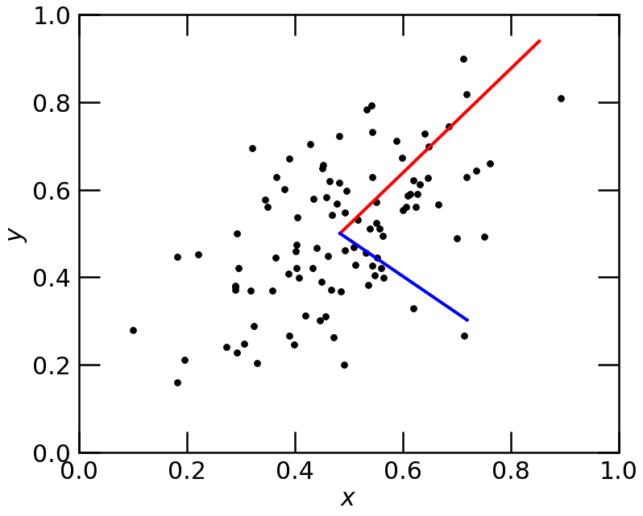

```python
xmin,xmax,ymin,ymax = 0.,1.,0.,1.

# Overplot the data and the eigenvector directions
fig, ax = plt.subplots(figsize=(12, 10))
ax.scatter(x,y,marker='o',s=60,color='black')

# Plot the 1st eigenvector with a length proportional to the 1st eigenvalue
l1_scale = 3.*np.sqrt(l1)     # this scaling by "3" is arbitrary for visualisation purposes
dx,dy = l1_scale*v1[0],l1_scale*v1[1]

X = [xmu,xmu+dx] # X axis: mu_x : mu_x + l1*v_1[x_value]
Y = [ymu,ymu+dy] # Y axis: mu_y : mu_y + l1*v_1[y_value]
ax.plot(X,Y,color='red')


# Plot the 2nd eigenvector with a length proportional to the 2nd eigenvalue
l2_scale = 3.*np.sqrt(l2) # this scaling by "3" is arbitrary for visualisation purposes
dx,dy = l2_scale*v2[0],l2_scale*v2[1]
ax.plot([xmu,xmu+dx],[ymu,ymu+dy],color='blue')
# X axis: mu_x : mu_x + l2*v_2[x_value]
# Y axis: mu_y : mu_y + l2*v_2[y_value]


# Complete the plot
ax.set_xlabel(r'$x$')
ax.set_ylabel(r'$y$')
ax.set_xlim(xmin,xmax)
ax.set_ylim(ymin,ymax)
#ax.gca().set_aspect('equal', adjustable='box')

plt.savefig("PCA_correlation_example_2D.png",dpi=300)
```

- Determine the values of PCA1 and PCA2 corresponding to each data point in a new coordinate.

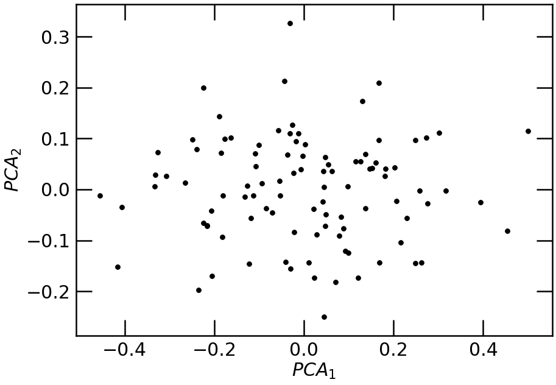

```python
# Determine the values of PCA1 and PCA2 corresponding to each data point
datapca = pca.transform(data)  # Project data to new coordinate PCA1, PCA2
#print(datapca)
pc1,pc2 = datapca[:,0],datapca[:,1]

# Make a scatter plot of PC1 and PC2
fig, ax = plt.subplots(figsize=(14, 10))
ax.scatter(pc1, pc2,marker='o',s=60,color='black')

plt.xlabel(r'$PCA_1$')
plt.ylabel(r'$PCA_2$')

plt.savefig("PCA_coordinate.png",dpi=300)
```

```python
len(pc1)
```

```
100
```

- The powerful of the PCA method is applied in reducing dimension of data. In the other words, approximating a dataset with fewer number of variables.
- Indeed, we can illustrate our dataset by reconstructing a model using 1 principal component. The best principal component is the eigenvectors that has highest eigenvalue. $$(x,y) = ( \bar{x}, \bar{y} ) + PCA_1 \vec{v_1}$$
- The blue data points are approximation of the original black data point.
- We can reduce 2 dimensional data to a model of a vector, or so-call data compression.
- The variance is the eigenvalue $\lambda_1$.

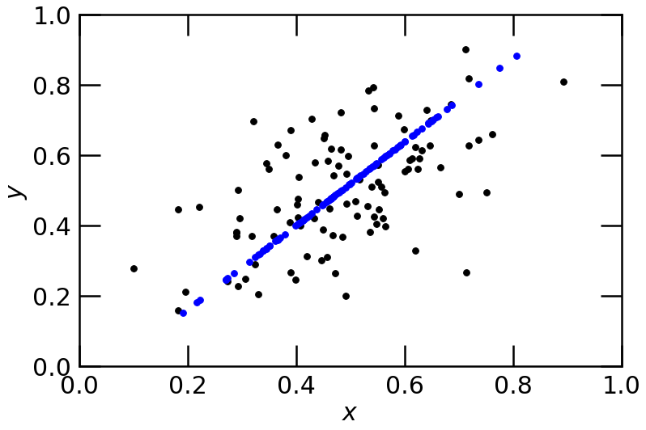

```python
# Plot original dataset
fig, ax = plt.subplots(figsize=(12, 8))

ax.scatter(x,y,marker='o',s=60,color='black')
# Make a prediction of the dataset using just 1 of the 2 principal components
x1 = xmu + pc1[:]*v1[0]
y1 = ymu + pc1[:]*v1[1]

#x2 = xmu + pc2[:]*v2[0]
#y2 = ymu + pc2[:]*v2[1]

# recover data
x_rc = xmu + pc1[:]*v1[0] + pc2[:]*v2[0]
y_rc = ymu + pc1[:]*v1[1] + pc2[:]*v2[1]

# Plot the prediction, which roughly models the original dataset along the principal eigenvector
# This is just a simple 2D example -- this technique is more powerful in higher dimensions
ax.scatter(x1,y1,marker='o',s=60,color='blue')
#ax.scatter(x2,y2,marker='o',s=60,color='red')
#ax.scatter(x_rc,y_rc,marker='o',s=60,color='m')

# Complete the plot
ax.set_xlabel(r'$x$')
ax.set_ylabel(r'$y$')
ax.set_xlim(xmin,xmax)
ax.set_ylim(ymin,ymax)
#plt.gca().set_aspect('equal', adjustable='box')

plt.savefig("PCA_reducing_dimension.png",dpi=300)
```

# 2. Bayesian method

- To understand Bayesian statistic, we need to understand the **conditional probability.**
- $P(A|B)$ means the probability of $A$ on the condition that $B$ has occurred.
- P(phở | Monday) = 1, P(noodle/Tuesday) = 0.
- The important Baye’s theorem:

$$P(A|B) = \frac{P(B|A) \, P(A)}{P(B)}$$

- Baye’s theorem applies for science:

$$P(model|data) = \frac{P(data|model) \, P(model)}{P(data)}$$

- **Posterior** probability $p(\theta , X)$ is the probability of the parameters $\theta$ given the evidence $X$.
- In contrast, **likelihood** function $p(X|\theta ) $ is the probability of the evidence $X$ given the parameters $\theta$.
- **Prior** probability distribution is an unknown quantity as parameters of a model.  
  Example: A Bayesian can argue that there is a prior probability of 10% of population has COVID-19. This probability should be updated every time we have new data. The prior probability is both the strong and weak point of Bayesian. The prior should be stated. If it is unknown we can just use a uninformative (wipe) prior.
- The prior probability is a logical necessity when evaluating the probability of a model.
- In the absence of information, a uniform (or constant) prior (distribution) is often supposed. This is equivalent to a fitting range.

## Example 1:

A 1-degree survey finds 20 quasars (our data D). What is the posterior probability distribution for the quasar number density $s$?

### solutions

- We are counting random events compared to a mean, so the Poisson distribution applies
- Mean number of quasars in area A $deg^2$ = 20 A
- $P(0) = exp(-20A) =0.01$ if $A=0.23 deg^2$

### Bayesian approach

- The posterior probability distribution $P(s|D) \propto P(D|s) P(s)$,
- It is equivalent as a Poisson distribution: $\rm Poisson(n=20|s) [Uniform \ prior]$

```python
#np.exp(-20*0.23)
```

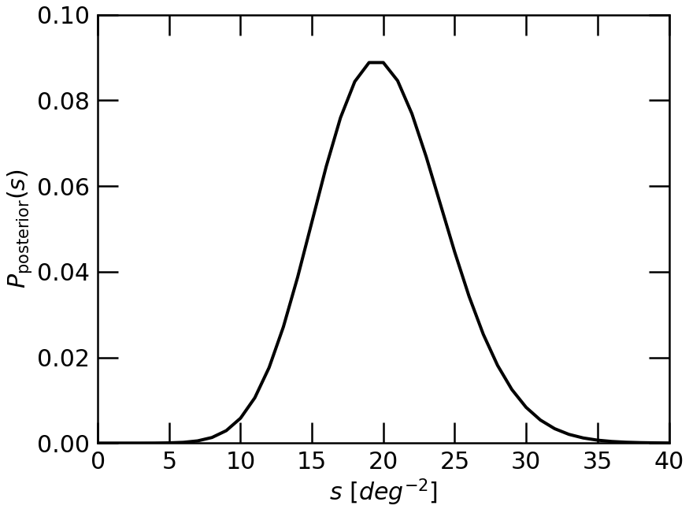

```python
mu1 = 20                                 # observable number of 20 quasar per degree square.
nmax = 40                                # maximum observed number of events to consider
n = np.arange(nmax+1)                    # variable for number of events
pdf_Poisson = stats.poisson.pmf(n,mu1)   # generate Poisson probability function

## ____________________________________________________

xmin,xmax = 0.,float(nmax)
ymin,ymax = 0.,0.1


fig, ax = plt.subplots(figsize=(13, 10))
ax.plot(n, pdf_Poisson,color='black',lw=4 )

#ax.axvline(x = np.round(mu1), color='red',linestyle='--', label=r'$\mu_1$: '+str(mu1) )   ## Vertical lines

#plt.plot([mu,mu],[ymin,ymax],color='black',linestyle='dotted')

ax.set_xlabel(r'$s \ [deg^{-2}]$')
ax.set_ylabel(r'$P_{\rm posterior}(s)$')
ax.set_xlim(xmin,xmax)
ax.set_ylim(ymin,ymax)

#ax.legend()
#ax.set_title(' Example Poisson distribution',fontsize=24,pad=15)


plt.savefig('Bayes_Poisson.png',dpi=300)
```

## Example 2:

A satellite observes 100 galaxies, 30 of which have elliptical galaxy (EG) shape.

### Solution by frequentist approach

**What is the best estimate of the AGN fraction and its error?**

- Estimate the probability of the Elliptic galaxy fraction as $p = N_{elliptic}/N_{total} = 30/100 = 0.3$
- There are 2 possible outcomes a galaxy has the "Elliptic" shape or "not an Elliptic") so the best estimation is the binomial distribution.
- Estimate the error in $N_{elliptic}$ as the standard deviation of the binomial distribution, $\sqrt{p(1-p)N_{total}} = 4.6$. Hence, the error in $p$ is $4.6/100 = 0.046$
- Answer: $p = 0.3 \pm 0.046$

### Solution by Bayesian approach:

**What is the posterior probability distribution of the elliptical shape fraction $p$ assuming (a) a uniform prior, (b) $p$ has a Gaussian distribution with mean 0.35 and r.m.s. 0.05?**

$$P(p|D) \propto P(D|p) \, P(p)$$

- $P(p|D)$ is the probability distribution of $p$ given the data $D$, which we want to determine.
- $P(D|p)$ is the probability of the data for a given value of $p$ (likelihood), as we studied by frequentist approack, the probability distribution is given by the Binomial distribution as $$P_{\rm Binomial}(n=30|N=100,p)$$
- $P(p)$ is the prior in $p$, which we take as a **uniform distribution** between $p=0$ and $p=1$.

> **(a) a uniform prior, the resulting calculation of $P(p|D)$**

```
0.001
```

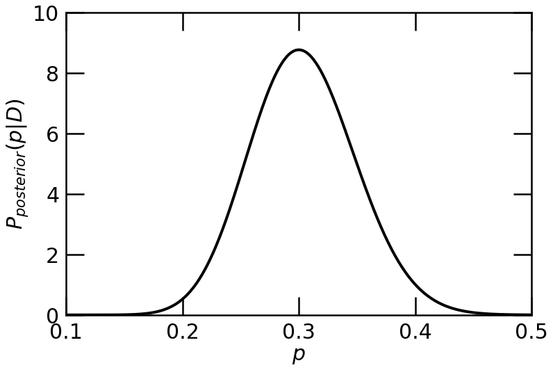

```python
n = 30           # Observed number of Elliptical galaxy (EG)

nmax = 100       # Total number of objects

# Range of values for the Elliptic fraction to evaluate
# This is the same as the width of the uniform prior in P(frac) or P(p)
xmin,xmax,nx = 0.1,0.5,400       ## you can change nx to have more data points in the plot!


# Array of values for the Elliptic galaxy fraction
dx = (xmax-xmin)/nx ; print(dx)
x = np.linspace(xmin+0.5*dx,xmax-0.5*dx,nx) # start from the first bin

#x = np.linspace(xmin,xmax,nx)
#print(x)

# Compute the (unnormalised) probability of each Elliptical galaxy fraction value
# This calculation uses Bayes' theorem: P(frac|n) \propto P(n|frac) P(frac)  or P(p|D) \propto P(D|p) P(p)
# P(n|frac) or P(D|p) is determined using the Binomial probability distribution
# P(frac) or P(p) is the prior, which we take as uniform and therefore do not include in the calculation
prob_posterior = np.empty(nx)
for i in range(nx):
  prob_posterior[i] = stats.binom.pmf(n,nmax,x[i])

#print('before normalization',prob_posterior)

# Normalise the probability distribution.  This ensures that \int P(x) dx = 1
# Expressing the integral as a sum, we are finding N such that N \sum P(x) dx = 1, or N = 1/\sum P(x) dx
prob_posterior /= np.sum(prob_posterior)*dx


# Plot the normalised posterior probability distribution for P(frac|n)
ymax = 10.

fig, ax = plt.subplots(figsize=(12, 8))
ax.plot(x,prob_posterior,color='black')
plt.xlim(xmin,xmax)
plt.ylim(0.,ymax)
plt.xlabel(r'$p$')
plt.ylabel(r'$P_{posterior}(p|D)$')

plt.savefig("Baye_posterior_galaxy.png",dpi=300)
```

```python
# These calculations work because the probability distribution is already normalised such that \int P(x) dx = 1
x1 = np.sum(x*prob_posterior*dx) # determine <x> by evaluating \int x P(x) dx = \sum x P(x) dx
x2 = np.sum((x**2)*prob_posterior*dx) # determine <x^2> by evaluating \int x^2 P(x) dx = \sum x^2 P(x) dx
mu = x1 # mean = <x>
sig = np.sqrt(x2 - x1**2) # standard deviation = \sqrt(<x^2> - <x>^2)
print('Mean =',mu)
print('Standard deviation =',sig)
```

```
Mean = 0.3039158356556867
Standard deviation = 0.04530760743511314
```

> **(b) $p$ has a Gaussian distribution with mean 0.35 and r.m.s. 0.05?, the resulting calculation of $P(p|D)$**

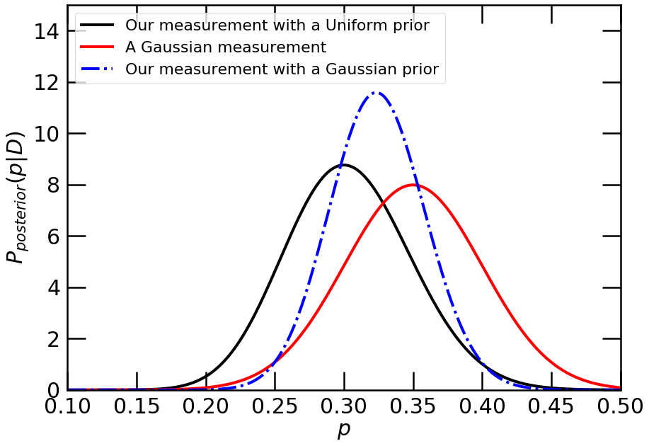

```python
n = 30        # Observed number of Elliptical galaxy (EG)

nmax = 100    # Total number of objects

# Range of values for the Elliptic fraction to evaluate
# This is the same as the width of the uniform prior in P(frac) or P(p)
# We can change this to be a different distribution.
xmin,xmax,nx = 0.1,0.5,400       ## you can change nx to have more data points in the plot!


# Array of values for the Elliptic galaxy fraction
dx = (xmax-xmin)/nx
x = np.linspace(xmin+0.5*dx,xmax-0.5*dx,nx)


# Compute the (unnormalised) probability of each Elliptical galaxy fraction value
# This calculation uses Bayes' theorem: P(frac|n) \propto P(n|frac) P(frac) or P(p|D) \propto P(D|p) P(p)
# P(n|frac) is determined using the Binomial probability distribution
# P(frac) P(p)  is the prior,
# The first case: the prior is a uniform (0,1) and therefore do not include in the calculation,
                 #there is only likelihooh: prob_likehood

## The second case: the prior is a Gaussian: prod_prior_G[i] = stats.norm.pdf(x[i],0.35,0.05)
                # The posterior = likelihood*Gaussian_prior
                # you can modify mean and sigma to have different visualizations

mu_G=0.35
sig_G=0.05
prob_posterior = np.empty(nx)
prob_likehood = np.empty(nx)
prod_prior_G = np.empty(nx)
for i in range(nx):
  prob_likehood[i] = stats.binom.pmf(n,nmax,x[i])    # this is equivalent as prior is a uniform
  prod_prior_G[i] = stats.norm.pdf(x[i],mu_G,sig_G)


prob_posterior = prob_likehood*prod_prior_G


# Normalise the probability distribution.  This ensures that \int P(x) dx = 1
# Expressing the integral as a sum, we are finding N such that N \sum P(x) dx = 1, or N = 1/\sum P(x) dx
prob_posterior /= np.sum(prob_posterior)*dx

prob_likehood /=np.sum(prob_likehood)*dx

prod_prior_G /=np.sum(prod_prior_G)*dx


# Plot the normalised posterior probability distribution for P(frac|n)
ymax = 15.

fig, ax = plt.subplots(figsize=(14, 10))
ax.plot(x,prob_likehood,color='black', label='Our measurement with a Uniform prior')
ax.plot(x,prod_prior_G,color='red', label='A Gaussian measurement')
ax.plot(x,prob_posterior,'-.',color='blue',label='Our measurement with a Gaussian prior' )

plt.legend(loc='upper left',fontsize=22)
plt.xlim(xmin,xmax)
plt.ylim(0.,ymax)
plt.xlabel(r'$p$')
plt.ylabel(r'$P_{posterior}(p|D)$')

plt.savefig("Baye_posterior_galaxy_Gaussian.png",dpi=300)
```

```python
# These calculations work because the probability distribution is already normalised such that \int P(x) dx = 1
x1 = np.sum(x*prob_posterior*dx) # determine <x> by evaluating \int x P(x) dx = \sum x P(x) dx
x2 = np.sum((x**2)*prob_posterior*dx) # determine <x^2> by evaluating \int x^2 P(x) dx = \sum x^2 P(x) dx
mu = x1 # mean = <x>
sig = np.sqrt(x2 - x1**2) # standard deviation = \sqrt(<x^2> - <x>^2)
print('Mean =',mu)
print('Standard deviation =',sig)
```

```
Mean = 0.32428459915139096
Standard deviation = 0.034330867668908846
```

## Marginalization

Now if we have have already determined the 2D posterior probability distribution of a model of 2-parameter, $P_{2D} (a, b)$ .

What is the probability distribution for parameter $a$, in case of all possible values of parameter $b$? [This is called as marginalization of parameter] $b$.

- For Gaussian variables: $Likelihood \propto exp (- \chi^2 /2)$.
- Convert the 2D $\chi^2$ grid into a 2D probability grid: $P_{2D} (a, b) \propto exp(-\chi^2/2)$.
- Normalize the grid: $\sum _b P_{2D} (a, b) = 1$
- Marginalization can be performed by integrating over one axis of the probability distribution: $P_{1D}(a) = \sum _b P_{2D} (a, b)$

**Lets apply the method for the straight model $y = ax+b$**

```
Best-fitting value of a = 0.27042421678017053
Best-fitting value of b = 0.4378789090155025
Minimum chi-squared $\chi^2$ = 7.502540606060829
Number of degrees of freedom = 28
p-value = 0.9999609922711097
```

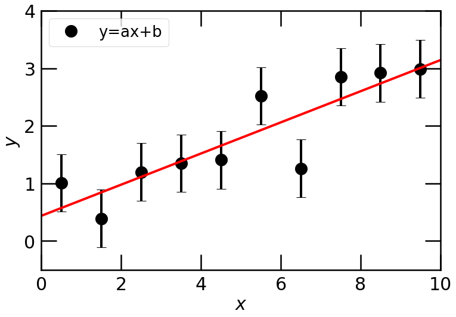

```python
import numpy as np
import matplotlib.pyplot as plt
from scipy import stats
from scipy.optimize import minimize
%matplotlib inline

# Function which evaluates the chi-squared value of a model y=a*x+b for the (x,y) dataset
def chisqstraightline(p,x,y,yerr):
  a,b = p[0],p[1]
  return np.sum(((y - (a*x + b))/yerr)**2)

# Read in the example dataset sampled from a straight line
# You will need to change the file path to the location where you've saved the data
direc = '/Users/USTH/TEACHING/SA2.7DataAnalysisandVisualization/'

data = np.loadtxt(direc+'/data/straightline.dat')
x,y,yerr = data[:,0],data[:,1],data[:,2]


# Find the best-fitting model parameters by minimising chi-squared (same code as in Class 3)
p0 = [0.2,1.]
result = minimize(chisqstraightline,p0,args=(x,y,yerr))
a,b = result['x']

minchisq = result['fun']          # chi-squared value corresponding to the best fit
dof = n-2                         # number of degrees of freedom (data points minus fitted parameters)
p = stats.chi2.sf(minchisq,dof) # probability of chi-squared to exceed the value we've found

print('Best-fitting value of a =', a)
print('Best-fitting value of b =', b)
print(r'Minimum chi-squared $\chi^2$ =', minchisq)
print('Number of degrees of freedom =', dof)
print('p-value =', p)


# Plot the dataset and best fit
xmin,xmax = 0.,10.
ymin,ymax = -0.5,4.


fig, ax = plt.subplots(figsize=(12, 8))
ax.plot(x,y,marker='o',markersize=20,color='black',linestyle='None',label='y=ax+b')
ax.errorbar(x,y,yerr=yerr,color='black',capsize=8,linestyle='None')
ax.plot([xmin,xmax],[a*xmin+b,a*xmax+b],color='red')

plt.legend()
plt.xlabel(r'$x$')
plt.ylabel(r'$y$')
plt.xlim(xmin,xmax)
plt.ylim(ymin,ymax)

plt.savefig("Baye_straight_line.png",dpi=300)
```

We now compute $\chi^2$ over a grid and convert this to a 2D probability distribution:

```
Minimum chi-squared = 7.5028281250000015
Best-fitting value of a = 0.27125
Best-fitting value of b = 0.4325
```

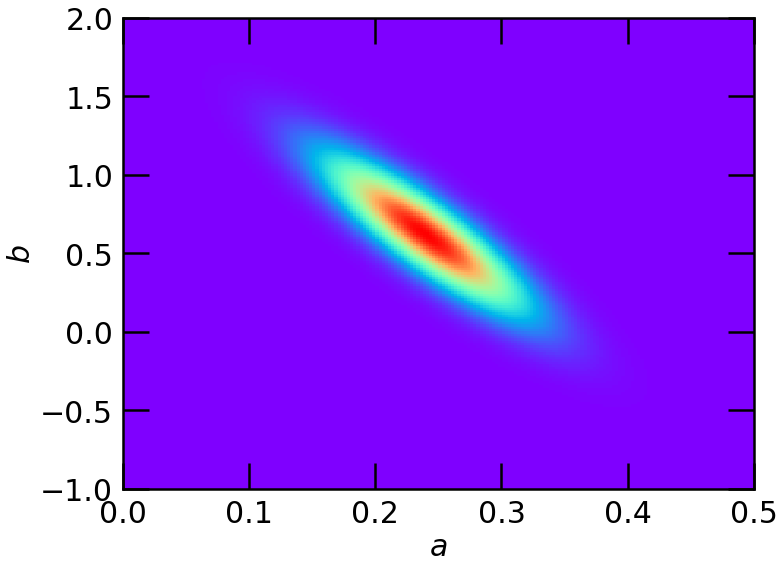

```python
# Determine the chi-squared values over a grid of model parameters a,b
# Set the range of parameters a,b and number of grid points
amin,amax,na = 0.,0.5,200
bmin,bmax,nb = -1.,2.,200

da,db = (amax-amin)/na,(bmax-bmin)/nb

alst = np.linspace(amin+0.5*da,amax-0.5*da,na)
blst = np.linspace(bmin+0.5*db,bmax-0.5*db,nb)

#1. make to 2D chi-square grid
#Evaluate the chi-squared value at each grid point (i.e. for each set of model parameters)
chisq2 = np.empty((na,nb))
for i in range(na):
  for j in range(nb):
    chisq2[i,j] = chisqstraightline([alst[i],blst[j]],x,y,yerr)


# Find the minimum value of chi-squared across the grid
minchisq = np.amin(chisq2)
print('Minimum chi-squared =',minchisq)

# Find the values of the model parameters at the point of minimum chi-squared
i,j = np.unravel_index( chisq2.argmin(), chisq2.shape )
a_m,b_m = alst[i],blst[j]
print('Best-fitting value of a =',a_m)
print('Best-fitting value of b =',b_m)


# 2. Convert the chi-squared values into a 2D probability grid, using P \propto exp(-chisq/2)
# We subtract the minimum chi-squared value in the exponent, to avoid numerical issues of exp(-large number)
prob2 = np.exp(-0.5*(chisq2-minchisq))

# 3. Normalise the probability grid such that \sum P(a,b) = 1
prob2 /= np.sum(prob2)

# Plot the probability grid as a greyscale
fig, ax = plt.subplots(figsize=(11, 8))
ax.imshow(prob2,aspect='auto',origin='lower',interpolation='nearest',clim=(0.,np.amax(prob2)),cmap='rainbow',extent=[amin,amax,bmin,bmax])
plt.xlabel(r'$a$')
plt.ylabel(r'$b$')
fig.tight_layout()

plt.savefig("Baye_2D_distribution.png",dpi=300)
```

Then we marginalize to obtain the posterior probability distributions for each parameter, $P(a)$ and $P(b)$:

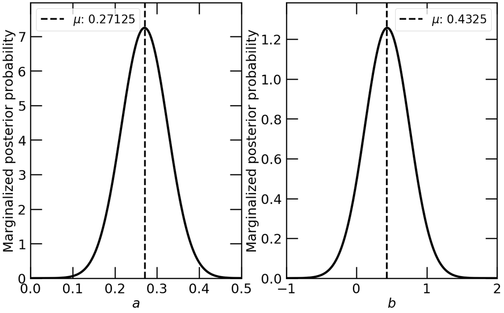

```python
# Marginalise the 2D probability distribution to obtain the 1D posterior probabilities of the 2 parameters
# Marginalise parameter b, by summing over the probabilities corresponding to all values of b
proba = np.sum(prob2,axis=1)

# Marginalise parameter a, by summing over the probabilities corresponding to all values of a
probb = np.sum(prob2,axis=0)

# Normalise the probabilities such that \int P(a) da = 1 (currently, \sum P(a) = 1)
proba /= da
probb /= db


# Plot the posterior probability distributions for a and b
fig, ax = plt.subplots(1, 2, figsize =(16,10))
ymin,ymax = 0.,1.1*np.amax(proba)
ax[0].plot(alst,proba,color='black',lw=5)
ax[0].axvline(x = a_m, color='black',linestyle='--', label=r'$\mu$: '+str(a_m) )   ## Vertical lines
ax[0].set_xlabel(r'$a$')
ax[0].set_ylabel('Marginalized posterior probability')
ax[0].set_xlim(amin,amax)
ax[0].set_ylim(ymin,ymax)
ax[0].legend()

ymin,ymax = 0.,1.1*np.amax(probb)
ax[1].plot(blst,probb,color='black',lw=5)
ax[1].axvline(x = b_m, color='black',linestyle='--', label=r'$\mu$: '+str(b_m) )   ## Vertical lines
ax[1].set_xlabel(r'$b$')
ax[1].set_ylabel('Marginalized posterior probability')
ax[1].set_xlim(bmin,bmax)
ax[1].set_ylim(ymin,ymax)
ax[1].legend()
fig.tight_layout()

plt.savefig("Baye_Marginalise.png",dpi=300)
```

By integrating under these distributions, we identify the 68% confidence regions:

```python
100 - 68.2
```

```
31.799999999999997
```

```
Lower limit of 68% confidence region for a = 0.21537194772022653
Upper limit of 68% confidence region for a = 0.32547443536273485
Lower limit of 68% confidence region for b = 0.120421311427411
Upper limit of 68% confidence region for b = 0.7552887844607601
```

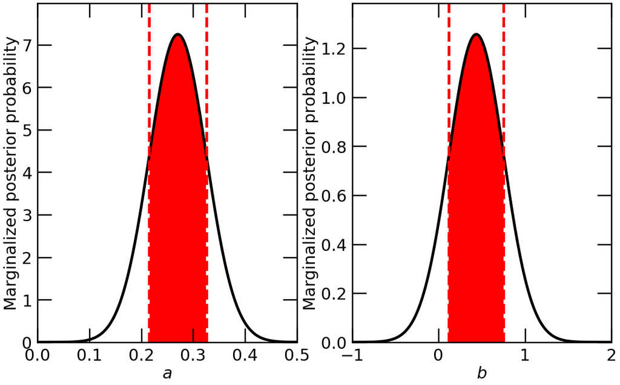

```python
# Function which identifies the parameter values enclosing the central 68.27% of the probability (1-sigma region)
# These values divide the total probability into regions containing ~16%, 68%, 16%

def get_err(prob,val):
  prob1 = prob/(0.01*np.sum(prob)) # normalise the probability such that it sums to 100
  lik = 31.73                      # corresponds to 100 minus the 1-sigma confidence probability
  likby2 = lik/2.      # ~ 16% probability enclosed in each of the 2 tails outside the 68% confidence region
  dval = val[1] - val[0]

  cumprob = np.cumsum(prob1) # cumulative probability, ranging from 0 to 100
  botval = np.interp(likby2,cumprob,val) + 0.5*dval # interpolate to determine the lower limit of the 68% region
  topval = np.interp(100.-likby2,cumprob,val) + 0.5*dval # interpolate to determine the upper limit of the 68% region
  return botval,topval


# Determine the lower and upper values of parameter a, enclosing 68% of the posterior probability distribution
abot,atop = get_err(proba,alst)
print('Lower limit of 68% confidence region for a =',abot)
print('Upper limit of 68% confidence region for a =',atop)


# Determine the lower and upper values of parameter b, enclosing 68% of the posterior probability distribution
bbot,btop = get_err(probb,blst)
print('Lower limit of 68% confidence region for b =',bbot)
print('Upper limit of 68% confidence region for b =',btop)

# Plot the probabilty distributions, shading the 68% confidence regions

fig, ax = plt.subplots(1,2,figsize=(16,10))

ymin,ymax = 0.,1.1*np.amax(proba)
i1,i2 = int((abot-amin)/da),int((atop-amin)/da) # array indices corresponding to 68% limits
ax[0].plot(alst,proba,color='black',lw=5)
ax[0].plot([abot,abot],[ymin,ymax],color='red',linestyle='dashed',lw=5)
ax[0].plot([atop,atop],[ymin,ymax],color='red',linestyle='dashed',lw=5)
ax[0].fill_between(alst[i1:i2],np.zeros(i2-i1),proba[i1:i2],color='red')
ax[0].set_xlabel(r'$a$')
ax[0].set_ylabel('Marginalized posterior probability')
ax[0].set_xlim(amin,amax)
ax[0].set_ylim(ymin,ymax)


#plt.subplot(122)
ymin,ymax = 0.,1.1*np.amax(probb)
i1,i2 = int((bbot-bmin)/db),int((btop-bmin)/db) # array indices corresponding to 68% limits
ax[1].plot(blst,probb,color='black',lw=5)
ax[1].plot([bbot,bbot],[ymin,ymax],color='red',linestyle='dashed',lw=5)
ax[1].plot([btop,btop],[ymin,ymax],color='red',linestyle='dashed',lw=5)
ax[1].fill_between(blst[i1:i2],np.zeros(i2-i1),probb[i1:i2],color='red')
ax[1].set_xlabel(r'$b$')
ax[1].set_ylabel('Marginalized posterior probability')
ax[1].set_xlim(bmin,bmax)
ax[1].set_ylim(ymin,ymax)
fig.tight_layout()

plt.savefig("Baye_Marginalise_68_CL.png",dpi=300)
```

## Bayesian correlation coefficient

In the lecture statistic, we measure the correlation coefficient and Pearson correlation of two variables. Using Bayesian statistics we can ask what is **the posterior probability distribution $\rho$** for the correlation coefficient given the measurement of Pearson value $r$:

$$P(\rho|r)$$

Assuming that $(x,y)$ data are drawn from a bivariate Gaussian distribution,

$$\rm P(X,Y) = \frac{1}{ 2 \pi \sigma_X \sigma_Y \sqrt{ 1- \rho^2 } } exp \left[ - \frac{1}{2(1-\rho^2)} \left( \frac{(X - \mu_X)^2}{ \sigma_X^2 } - 2 \rho \frac{(X-\mu_X)(Y-\mu_Y)}{ \sigma_X \sigma_Y }+ \frac{(Y- \mu_Y)^2}{ \sigma_Y^2 } \right) \right]$$

there is an analytic relation for this:

$$P(\rho|r) \propto \frac{(1-\rho^2)^{(N-1)/2}}{(1-\rho r)^{N-3/2}} \left( 1 + \frac{1}{N - 1/2} \frac{1+\rho r}{8} + ... \right)$$

Here's how this may be evaluated for the example above:

[output not shown]

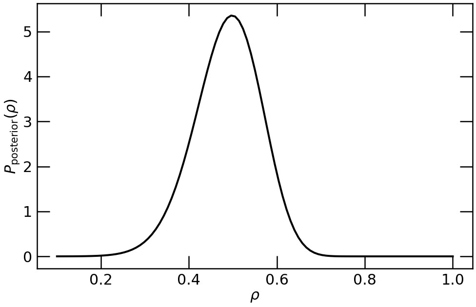

```python
# Build the posterior probability distribution for the correlation coefficient rho
# Range of values of rho
xmin,xmax,n = 0.1,1.,101
x = np.linspace(xmin,xmax,n)   ## x = rho
dx = (xmax-xmin)/n             ## N = 101

r=0.5                         ## assume r=0.5
# Evaluate the different terms inside the above equation for P(rho|r), separated for clarity
t1 = (1.-x**2)**(0.5*(n-1))
t2 = (1.-x*r)**(n-1.5)
t3 = (1. + (1./(n-0.5))*((1.+r*x)/8.))

# Combine the terms to determine P(rho|r)
y = (t1/t2)*t3


# Normalise the probability distribution such that \int P(rho) drho = 1
y /= np.sum(y)*dx


# Plot the posterior probability distribution for rho
fig, ax = plt.subplots(figsize=(16,10))
ax.plot(x,y,color='black',lw=4)
plt.xlabel(r'$\rho$')
plt.ylabel(r'$P_{\rm posterior}(\rho)$')

plt.savefig("Bayesian_test.png",dpi=300)
```

## Advanced Activity 1 (Option)

Use Bayesian correlation testing to determine the posterior probability distribution of the correlation coefficient of Lemaitre and Hubble’s distance vs. velocity data, assuming a uniform prior.

## Advanced Activity 2 (Option)

Let take again the supernovae dark matter-redshift data.

- Convert the $\chi^2$ values into a **joint 2D probability distribution** in $(\Omega_m,\Omega_\Lambda)$
- Marginalize this probability distribution to obtain the **1D posterior probability distributions** for $\Omega_m$ and $\Omega_\Lambda$
- Determine the **68% confidence regions** for $\Omega_m$ and $\Omega_\Lambda$